# [IPO1] Prepare data (and impute IPO)

## Read data

```r
df_patient <- read.csv("./data/IPO_Beteg_TCI_SCL2_datjav.csv", header=T, sep=",")
dim(df_patient)
```

```
[1]  188 1399
```

```r
table(df_patient$KOR2 < 18)  #KOR2=age
```

```
FALSE  TRUE
  173     1
```

Unfortunately there is a 17-year old in the sample that has to be removed.

```r
df_patient <- subset(df_patient, KOR2 > 17 | is.na(KOR2))
dim(df_patient)
```

```
[1]  187 1399
```

So this leaves 187 patients’ data on 1399 variables for analysis.

# Missing data

Let’s have a look at missing data structure of IPO to (hopefully) save some data by imputing.

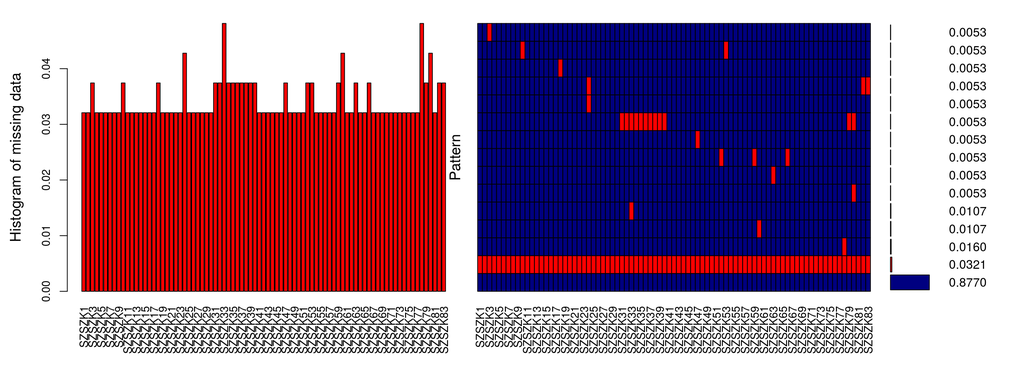

```r
library(VIM)
IPO_items <- df_patient[grep("^SZSZK", names(df_patient), value=T)]
aggr_plot <- aggr(IPO_items, col=c('navyblue','red'), numbers=T, sortVars=F,
                  labels=names(IPO_items), cex.axis=0.9, cex.lab = 1.2, gap=1.2,
                  combined=F,
                  ylab=c("Histogram of missing data","Pattern"))
```

So we have 181 rows with SOME data and 6 rows with no data on IPO.  
Note the completely missing data rows at the end (last 6 rows). These will need to be omitted for imputation purposes.

```r
rowSums(is.na(IPO_items))
```

```
  1   2   3   4   5   6   7   8   9  10  11  12  13  14  15  16  17  18  19  20  21  22  23  24  25
  0   0   0   0   0   0   0   0   0   0   0   0   0   0  12   0   1   0   0   0   3   0   0   0   0
 26  27  28  29  30  31  32  33  34  35  36  37  38  39  40  41  42  43  44  45  46  47  48  49  50
  0   0   0   0   0   0   0   0   0   0   0   0   0   0   0   0   0   0   0   0   0   1   0   0   0
 52  53  54  55  56  57  58  59  60  61  62  63  64  65  66  67  68  69  70  71  72  73  74  75  76
  1   0   0   0   0   0   0   0   0   0   0   0   0   0   0   0   0   0   0   0   0   0   0   0   0
 77  78  79  80  81  82  83  84  85  86  87  88  89  90  91  92  93  94  95  96  97  98  99 100 101
  0   0   0   0   0   0   0   0   0   0   0   0   1   0   1   0   0   0   0   0   1   0   0   0   1
102 103 104 105 106 107 108 109 110 111 112 113 114 115 116 117 118 119 120 121 122 123 124 125 126
  1   0   0   0   0   0   0   0   0   0   0   0   0   0   0   0   0   0   0   0   0   0   0   0   0
127 128 129 130 131 132 133 134 135 136 137 138 139 140 141 142 143 144 145 146 147 148 149 150 151
  0   0   0   1   0   0   1   0   0   0   0   0   0   0   0   0   0   0   0   0   0   1   0   3   0
152 153 154 155 156 157 158 159 160 161 162 163 164 165 166 167 168 169 170 171 172 173 174 175 176
  0   0   0   0   1   0   0   0   0   0   0   0   0   0   0   0   0   0   0   0   0   0   0   0   0
177 178 179 180 181 182 183 184 185 186 187 188
  0   2   0   0   1   0  83  83  83  83  83  83
```

# Data imputation

```r
# So we want to get rid of rows which contain no data.
IPO_items_noBlankRow <- df_patient[grep("^SZSZK", names(df_patient), value=T)][!(rowSums(is.na(IPO_items)) == "83"),]

# The rest can be inputed:
dim(IPO_items_noBlankRow)
```

```
[1] 181  83
```

```r
# let's do the imputation
library(mice)
IPO_items_imputed <- mice(IPO_items_noBlankRow, m=2, maxit=50, method="pmm", seed=1239)
```

```r
# and pick the 2nd imputed matrix as the final dataset which hopefully contains no missing data
IPO_items_complete <- complete(IPO_items_imputed, 2)
dim(IPO_items_complete)
```

```
## [1] 181  83
```

So, are there any missing data?

```r
rowSums(is.na(IPO_items_complete))
```

```
  1   2   3   4   5   6   7   8   9  10  11  12  13  14  15  16  17  18  19  20  21  22  23  24  25
  0   0   0   0   0   0   0   0   0   0   0   0   0   0   0   0   0   0   0   0   0   0   0   0   0
 26  27  28  29  30  31  32  33  34  35  36  37  38  39  40  41  42  43  44  45  46  47  48  49  50
  0   0   0   0   0   0   0   0   0   0   0   0   0   0   0   0   0   0   0   0   0   0   0   0   0
 52  53  54  55  56  57  58  59  60  61  62  63  64  65  66  67  68  69  70  71  72  73  74  75  76
  0   0   0   0   0   0   0   0   0   0   0   0   0   0   0   0   0   0   0   0   0   0   0   0   0
 77  78  79  80  81  82  83  84  85  86  87  88  89  90  91  92  93  94  95  96  97  98  99 100 101
  0   0   0   0   0   0   0   0   0   0   0   0   0   0   0   0   0   0   0   0   0   0   0   0   0
102 103 104 105 106 107 108 109 110 111 112 113 114 115 116 117 118 119 120 121 122 123 124 125 126
  0   0   0   0   0   0   0   0   0   0   0   0   0   0   0   0   0   0   0   0   0   0   0   0   0
127 128 129 130 131 132 133 134 135 136 137 138 139 140 141 142 143 144 145 146 147 148 149 150 151
  0   0   0   0   0   0   0   0   0   0   0   0   0   0   0   0   0   0   0   0   0   0   0   0   0
152 153 154 155 156 157 158 159 160 161 162 163 164 165 166 167 168 169 170 171 172 173 174 175 176
  0   0   0   0   0   0   0   0   0   0   0   0   0   0   0   0   0   0   0   0   0   0   0   0   0
177 178 179 180 181 182
  0   0   0   0   0   0
```

No more missing data here.

Finally, save the final, imputed version of IPO items.

```r
dim(IPO_items_complete)
```

```
[1] 181  83
```

```r
write.csv(IPO_items_complete, file="./data/IPO_items_complete.csv")
```